# Proyecto Final | Series de Tiempo

## Resumen de modelos

Ahora observemos un resumen de las tolerancias de error de todos los modelos vistos, en donde el modelo Holt-Winters multiplicativo simple es el que menor porcentaje tiene.

| **Modelo** | **MAPE** |
| --- | --- |
| Holt-Winters Multiplicativo Simple | 2.29% |
| Promedio Móvil Modificado | 3.12% |
| Promedio Móvil | 3.71% |
| Promedio Móvil Doble | 6.12% |
| Holt-Winters Aditivo Simple | 6.54% |
| Suavizamiento Exponencial Tipo Optimal con a=0.1 | 6.59% |
| Suavizamiento Exponencial Tipo Simple con a=0.1 | 6.64% |
| Método de Holt Simple | 6.72% |
| Método de Holt Optimal | 6.87% |
| Suavizamiento Exponencial Tipo Simple con a=0.5 | 6.89% |
| Suavizamiento Exponencial Tipo Optimal con a=0.5 | 6.90% |
| Media Movil Tipo “r” | 6.94% |
| Media Movil Tipo “e” | 6.99% |
| Suavizamiento Exponencial Tipo Simple con a=0.8 | 7.07% |
| Suavizamiento Exponencial Tipo Optimal con a=0.8 | 7.07% |
| Media Móvil Tipo “w” | 7.15% |
| Promedio Ponderado | 7.20% |
| Promedio Móvil Triangular | 10.52% |

Gráfica que representa el pronóstico elegido, debido a que el error generado es el más pequeño de los modelos que se seleccionaron para su validación.

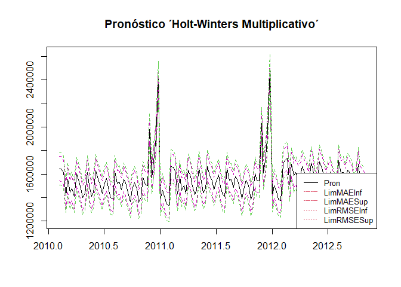

```r
# Gráfica de modelo seleccionado
y <- ts(info_tda_1$Weekly_Sales, start = decimal_date(as.Date("2010-02-05")), frequency = 52)
est_hwm<-hw(y, h = 2, seasonal = c("multiplicative"),level = c(80, 95),initial = c("simple"), alpha = NULL, beta = NULL, gamma = NULL)

fhwm<-est_hwm$fitted
fhwm_ts<-ts(fhwm,start = decimal_date(as.Date("2010-02-05")), frequency = 52)
fhwmt_ts<-rep(0,144)
for(t in 3:144) fhwmt_ts[t]<-fhwm_ts[t-2]
for(t in 1:2) fhwmt_ts[t]<-NA
yt<-rep(0,144)
for(t in 1:142) yt[t]<-y[t]
for(t in 143:144) yt[t]<-NA
yt_ts<-ts(yt,start = decimal_date(as.Date("2010-02-05")), frequency = 52)

yd_pr_2 <- ts(fhwm_ts, start = decimal_date(as.Date("2010-02-05")), frequency = 52)

lis_mae<-fhwm_ts+mae_est_hwm
lii_mae<-fhwm_ts-mae_est_hwm
lis_rmse<-fhwm_ts+rmse_est_hwm
lii_rmse<-fhwm_ts-rmse_est_hwm
ts.plot(yd_pr_2, lis_mae, lii_mae, lis_rmse, lii_rmse, xlab=NULL, main="Pronóstico ´Holt-Winters Multiplicativo´", lty=c(1,2,2,2,2), col = c(1,6,6,3,3))
legend(x="bottomright",legend=c("Pron","LimMAEInf", "LimMAESup","LimRMSEInf","LimRMSESup"),col=c(1,2,2,2,2),lty=c(1,6,6,3,3), cex=0.8)
```

## Modelos de Descomposición

Este tipo de descomposición exhibe la variación constante de la serie. Y por medio de esta gráfica se representa la estacionalidad de la serie, mostrada en los dos picos en la serie. De los cuales podemos inferir que marcan un impulso en las ventas semanales por la temporada decembrina, incluso las fechas coinciden .

### Aditivo

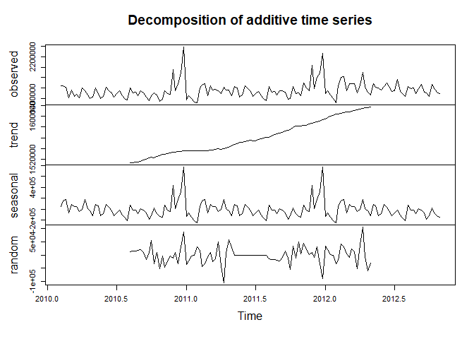

```r
y <- ts(info_tda_1$Weekly_Sales, start = decimal_date(as.Date("2010-02-05")), frequency = 52)
dec_y <-decompose (y, type = c("additive", "multiplicative"))

plot(dec_y)
```